# Exploratory Data Analysis

Gaja Matassa

Date: July 24, 2025

```r
for (i in 1:length(params))
  print(paste('Parameter:', names(params)[i], ' - Value:', params[[i]], '- Class:', class(params[[i]])))
## [1] "Parameter: InputFolder  - Value: ~/EGCLCclones/1.Preprocessing/Output/methyldackel - Class: character"
## [1] "Parameter: OutputFolder  - Value: ~/EGCLCclones/2.PreliminaryAnalysis/ - Class: character"
```

```r
InputFolder <- params$InputFolder
OutputFolder <- params$OutputFolder

if (dir.exists(OutputFolder) == FALSE) {
  dir.create(OutputFolder, recursive=TRUE)
}
```

**Colors for figures**

```r
sample_colors <- c("hiPSC_rep1" = "#dd1c77", "hiPSC_rep2" = "#dd1c77", "hiPSC_rep3" = "#dd1c77", "hiPSC_rep4" = "#dd1c77",
                   "hiPSC_rep5" = "#dd1c77",
                   "iMeLC_rep1" = "#377eb8", "iMeLC_rep2" = "#377eb8", "iMeLC_rep3" = "#377eb8", "iMeLC_rep4" = "#377eb8",
                   "hPGCLC_rep1" = "#4daf4a", "hPGCLC_rep2" = "#4daf4a", "hPGCLC_rep3" = "#4daf4a",
                   "hEGCLC_p5_rep1" = "#ff7f00", "hEGCLC_p5_rep2" = "#ff7f00", "hEGCLC_p5_rep3" = "#ff7f00",
                   "hEGCLC_p10_rep1" = "#ffc400", "hEGCLC_p10_rep2" = "#ffc400", "hEGCLC_p10_rep3" = "#ffc400")

cellTypes_colors <- c(hiPSCs ="#dd1c77", iMeLCs ="#377eb8", hPGCLCs ="#4daf4a", hEGCLCs_p5 = "#ff7f00", hEGCLCs_p10 = "#ffc400")
```

# 1. Loading data

BedGraph files in input are already merged (from individual Cytosines in a CpG to per-CpG metrics) and filtered (threshold: 10 reads). Here bedIntersect was already used to keep only on-bait CpGs.

```r
bdg_files <-  list.files(path = InputFolder, pattern = '*\\.bedGraph', full.names = TRUE) #output from our preprocessing
```

```r
bdg_files_filtered <- bdg_files[grep("filtered", bdg_files)]
```

```r
sample_anno <- data.frame("SampleID" = c("hiPSC_rep5", "hEGCLC_p10_rep1", "hEGCLC_p10_rep2", "hEGCLC_p10_rep3"), "OriginalID" = c("hiPSC", "hEGCLC_clone2", "hEGCLC_clone9", "hEGCLC_clone31"), "Type" = c("hiPSCs", "hEGCLCs_p10", "hEGCLCs_p10", "hEGCLCs_p10"), "Line" = rep("CTL08A", 4), "passage" = c("26", "10", "10", "10"))
sample_anno$Type <- factor(sample_anno$Type)
rownames(sample_anno) <- sample_anno$SampleID
```

Match order

```r
bdg_files_filtered <- bdg_files_filtered[order(match(sub(".filtered.bedGraph", "", basename(bdg_files_filtered)), sample_anno$SampleID))]
```

Adding previous experiment samples

```r
bdg_files2 <-  list.files(path = "~/DataDir/0.Preprocessing/Output", pattern = '*\\.bedGraph', full.names = TRUE) #output from our preprocessing
```

```r
bdg_files_filtered2 <- bdg_files2[grep("filtered", bdg_files2)]
```

```r
sample_anno2 <- read.table("~/DataDir/1.PreliminaryAnalysis/Input/SampleAnno.txt", sep='\t', header=TRUE)

sample_anno2[sample_anno2$Type %in% "hEGCLCs", "Type"] <- "hEGCLCs_p5"
sample_anno2$SampleID <- sub("hEGCLC_", "hEGCLC_p5_", sample_anno2$SampleID)
rownames(sample_anno2) <- sample_anno2$SampleID
```

Keeping only bedGraph files of selected samples.

```r
bdg_files_filtered2 <- bdg_files_filtered2[which(grepl(paste(sample_anno2$OriginalID, collapse = "|"), bdg_files_filtered2) )]
```

Match order

```r
bdg_files_filtered2 <- bdg_files_filtered2[order(match(sub(".filtered.bedGraph", "", basename(bdg_files_filtered2)), sample_anno2$OriginalID))]
```

```r
sample_anno <- plyr::rbind.fill(sample_anno2, sample_anno)
rownames(sample_anno) <- sample_anno$SampleID
bdg_files_filtered <- c(bdg_files_filtered2, bdg_files_filtered)

sample_anno <- rbind(sample_anno[1:4,], sample_anno[15,], sample_anno[5:14,], sample_anno[16:18,])
```

Match order

```r
bdg_files_filtered <- bdg_files_filtered[order(match(sub(".filtered.bedGraph", "", basename(bdg_files_filtered)), sample_anno$OriginalID))]
```

# 2. Reading bedgraph files with `read.bismark` from **bsseq** package

## 2.1 Generation of BSseq object

`strandCollapse = FALSE` because MethylDackel has an option to destrand data when methylation calls are made so that the output is already destranded.

```r
if(identical(sub(".filtered.bedGraph", "", basename(bdg_files_filtered)), sample_anno$OriginalID)){
  bsseq_obj <- bsseq::read.bismark(
      files = bdg_files_filtered,
      colData = sample_anno,
      rmZeroCov = FALSE,
      strandCollapse = FALSE #false if MethylDackel is used because MethylDackel has an option to destrand data when methylation calls are made so that the output is already destranded.
  )
} else{stop("Sample names don't match between Bedgraph file and metadata")}
```

- The number of samples in the BSSeq object is 18.
- The number of CpGs in the BSSeq object is 3734728.

## 2.2 Exploration of BSseq object

```r
bsseq::pData(bsseq_obj)
```

```
## DataFrame with 18 rows and 12 columns
##                        SampleID     OriginalID        Type       Day     Batch
##                     <character>    <character> <character> <integer> <integer>
## hiPSC_rep1           hiPSC_rep1             2S      hiPSCs        NA         2
## hiPSC_rep2           hiPSC_rep2             3S      hiPSCs        NA         3
## hiPSC_rep3           hiPSC_rep3             5S      hiPSCs        NA         5
## hiPSC_rep4           hiPSC_rep4             4S      hiPSCs        NA         4
## hiPSC_rep5           hiPSC_rep5          hiPSC      hiPSCs        NA        NA
## ...                         ...            ...         ...       ...       ...
## hEGCLC_p5_rep2   hEGCLC_p5_rep2       3_EG9_SL  hEGCLCs_p5        NA         3
## hEGCLC_p5_rep3   hEGCLC_p5_rep3      3_EG31_SL  hEGCLCs_p5        NA         3
## hEGCLC_p10_rep1 hEGCLC_p10_rep1  hEGCLC_clone2 hEGCLCs_p10        NA        NA
## hEGCLC_p10_rep2 hEGCLC_p10_rep2  hEGCLC_clone9 hEGCLCs_p10        NA        NA
## hEGCLC_p10_rep3 hEGCLC_p10_rep3 hEGCLC_clone31 hEGCLCs_p10        NA        NA
##                        Line     Clone      Medium  PercOxigen PercEfficiency
##                 <character> <integer> <character> <character>    <character>
## hiPSC_rep1           CTL08A        NA
## hiPSC_rep2           CTL08A        NA
## hiPSC_rep3           CTL08A        NA
## hiPSC_rep4           CTL08A        NA
## hiPSC_rep5           CTL08A        NA          NA          NA             NA
## ...                     ...       ...         ...         ...            ...
## hEGCLC_p5_rep2       CTL08A         9     StemFit      low_ox
## hEGCLC_p5_rep3       CTL08A        31     StemFit      low_ox
## hEGCLC_p10_rep1      CTL08A        NA          NA          NA             NA
## hEGCLC_p10_rep2      CTL08A        NA          NA          NA             NA
## hEGCLC_p10_rep3      CTL08A        NA          NA          NA             NA
##                       Notes     passage
##                 <character> <character>
## hiPSC_rep1                           NA
## hiPSC_rep2                           NA
## hiPSC_rep3                           NA
## hiPSC_rep4                           NA
## hiPSC_rep5               NA          26
## ...                     ...         ...
## hEGCLC_p5_rep2                       NA
## hEGCLC_p5_rep3                       NA
## hEGCLC_p10_rep1          NA          10
## hEGCLC_p10_rep2          NA          10
## hEGCLC_p10_rep3          NA          10
```

`bsseq` package assumes that the following data has been extracted from alignments:

1. genomic positions, including chromosome and location, for methylation loci.The genomic positions are stored in the bsseq object as a `GRanges` object. `GRanges` are general genomic regions; they represent a single base methylation loci as an interval of width 1 (which may seem a bit strange, but they said there are good reasons for this).

```r
head(GenomicRanges::granges(bsseq_obj))
```

```
## GRanges object with 6 ranges and 0 metadata columns:
##       seqnames    ranges strand
##          <Rle> <IRanges>  <Rle>
##   [1]     chr1     10468      *
##   [2]     chr1     10470      *
##   [3]     chr1     10483      *
##   [4]     chr1     10488      *
##   [5]     chr1     10492      *
##   [6]     chr1     10496      *
##   -------
##   seqinfo: 25 sequences from an unspecified genome; no seqlengths
```

**Methylation calls are from these chromosomes:**

```r
levels(bsseq_obj@rowRanges@seqnames@values)
```

```
##  [1] "chr1"  "chr2"  "chr3"  "chr4"  "chr5"  "chr6"  "chr7"  "chr8"  "chr9"
## [10] "chr10" "chr11" "chr12" "chr13" "chr14" "chr15" "chr16" "chr17" "chr18"
## [19] "chr19" "chr20" "chr21" "chr22" "chrX"  "chrY"  "chrM"
```

2. a (matrix) of M (Methylation) values, describing the number of read supporting methylation covering a single loci. Each row in this matrix is a methylation loci and each column is a sample.

```r
Meth_matrix <- bsseq::getCoverage(bsseq_obj, type = 'M')
head(Meth_matrix)
```

```
##      hiPSC_rep1 hiPSC_rep2 hiPSC_rep3 hiPSC_rep4 hiPSC_rep5 iMeLC_rep1
## [1,]         16         18         19         21         46         18
## [2,]         18         20         22         25         50         24
## [3,]         23         21         23         25         60         27
## [4,]         23         22         25         26         62         22
## [5,]         24         21         26         27         58         27
## [6,]         23         22         27         27         58         25
##      iMeLC_rep2 iMeLC_rep3 iMeLC_rep4 hPGCLC_rep1 hPGCLC_rep2 hPGCLC_rep3
## [1,]         28         27         16          13          11          23
## [2,]         32         28         17          17          12          28
## [3,]         39         30         19          19          16          28
## [4,]         40         30         21          18          16          25
## [5,]         40         30         23          20          15          25
## [6,]         42         30         23          19          17          26
##      hEGCLC_p5_rep1 hEGCLC_p5_rep2 hEGCLC_p5_rep3 hEGCLC_p10_rep1
## [1,]             40             31             27              32
## [2,]             45             36             32              37
## [3,]             49             40             44              47
## [4,]             52             43             42              52
## [5,]             51             46             42              53
## [6,]             53             49             47              53
##      hEGCLC_p10_rep2 hEGCLC_p10_rep3
## [1,]              19              26
## [2,]              22              27
## [3,]              29              31
## [4,]              28              32
## [5,]              28              33
## [6,]              28              32
```

3. a (matrix) of Cov (Coverage) values, describing the total number of reads covering a single loci. Each row in this matrix is a methylation loci and each column is a sample.

```r
Cov_matrix <- bsseq::getCoverage(bsseq_obj, type = 'Cov')
head(Cov_matrix)
```

```
##      hiPSC_rep1 hiPSC_rep2 hiPSC_rep3 hiPSC_rep4 hiPSC_rep5 iMeLC_rep1
## [1,]         19         21         23         25         50         24
## [2,]         18         20         22         25         51         25
## [3,]         23         22         23         26         62         28
## [4,]         23         23         26         27         62         27
## [5,]         24         22         27         29         58         28
## [6,]         23         23         28         30         58         26
##      iMeLC_rep2 iMeLC_rep3 iMeLC_rep4 hPGCLC_rep1 hPGCLC_rep2 hPGCLC_rep3
## [1,]         35         31         19          20          16          29
## [2,]         34         29         18          17          12          28
## [3,]         39         32         22          22          16          29
## [4,]         41         32         24          21          16          28
## [5,]         42         32         25          24          16          27
## [6,]         42         32         27          23          17          30
##      hEGCLC_p5_rep1 hEGCLC_p5_rep2 hEGCLC_p5_rep3 hEGCLC_p10_rep1
## [1,]             45             43             37              34
## [2,]             46             37             34              38
## [3,]             54             42             46              49
## [4,]             55             46             47              53
## [5,]             55             48             48              53
## [6,]             56             51             49              54
##      hEGCLC_p10_rep2 hEGCLC_p10_rep3
## [1,]              24              29
## [2,]              25              27
## [3,]              30              31
## [4,]              29              33
## [5,]              29              33
## [6,]              29              34
```

0/0 gives NaN, this is the case when 0 methylated reads mapping on that region over 0 total reads mapping on that region.

Methylation Proportions/Levels = Meth_matrix/Cov_matrix

```r
MethPerc_matrix <- (Meth_matrix/Cov_matrix)*100
head(MethPerc_matrix)
```

```
##      hiPSC_rep1 hiPSC_rep2 hiPSC_rep3 hiPSC_rep4 hiPSC_rep5 iMeLC_rep1
## [1,]   84.21053   85.71429   82.60870   84.00000   92.00000   75.00000
## [2,]  100.00000  100.00000  100.00000  100.00000   98.03922   96.00000
## [3,]  100.00000   95.45455  100.00000   96.15385   96.77419   96.42857
## [4,]  100.00000   95.65217   96.15385   96.29630  100.00000   81.48148
## [5,]  100.00000   95.45455   96.29630   93.10345  100.00000   96.42857
## [6,]  100.00000   95.65217   96.42857   90.00000  100.00000   96.15385
##      iMeLC_rep2 iMeLC_rep3 iMeLC_rep4 hPGCLC_rep1 hPGCLC_rep2 hPGCLC_rep3
## [1,]   80.00000   87.09677   84.21053    65.00000       68.75    79.31034
## [2,]   94.11765   96.55172   94.44444   100.00000      100.00   100.00000
## [3,]  100.00000   93.75000   86.36364    86.36364      100.00    96.55172
## [4,]   97.56098   93.75000   87.50000    85.71429      100.00    89.28571
## [5,]   95.23810   93.75000   92.00000    83.33333       93.75    92.59259
## [6,]  100.00000   93.75000   85.18519    82.60870      100.00    86.66667
##      hEGCLC_p5_rep1 hEGCLC_p5_rep2 hEGCLC_p5_rep3 hEGCLC_p10_rep1
## [1,]       88.88889       72.09302       72.97297        94.11765
## [2,]       97.82609       97.29730       94.11765        97.36842
## [3,]       90.74074       95.23810       95.65217        95.91837
## [4,]       94.54545       93.47826       89.36170        98.11321
## [5,]       92.72727       95.83333       87.50000       100.00000
## [6,]       94.64286       96.07843       95.91837        98.14815
##      hEGCLC_p10_rep2 hEGCLC_p10_rep3
## [1,]        79.16667        89.65517
## [2,]        88.00000       100.00000
## [3,]        96.66667       100.00000
## [4,]        96.55172        96.96970
## [5,]        96.55172       100.00000
## [6,]        96.55172        94.11765
```

This matrix can also be obtained like this:

```r
head(getMeth(BSseq = bsseq_obj, type = "raw"))
```

```
##      hiPSC_rep1 hiPSC_rep2 hiPSC_rep3 hiPSC_rep4 hiPSC_rep5 iMeLC_rep1
## [1,]  0.8421053  0.8571429  0.8260870  0.8400000  0.9200000  0.7500000
## [2,]  1.0000000  1.0000000  1.0000000  1.0000000  0.9803922  0.9600000
## [3,]  1.0000000  0.9545455  1.0000000  0.9615385  0.9677419  0.9642857
## [4,]  1.0000000  0.9565217  0.9615385  0.9629630  1.0000000  0.8148148
## [5,]  1.0000000  0.9545455  0.9629630  0.9310345  1.0000000  0.9642857
## [6,]  1.0000000  0.9565217  0.9642857  0.9000000  1.0000000  0.9615385
##      iMeLC_rep2 iMeLC_rep3 iMeLC_rep4 hPGCLC_rep1 hPGCLC_rep2 hPGCLC_rep3
## [1,]  0.8000000  0.8709677  0.8421053   0.6500000      0.6875   0.7931034
## [2,]  0.9411765  0.9655172  0.9444444   1.0000000      1.0000   1.0000000
## [3,]  1.0000000  0.9375000  0.8636364   0.8636364      1.0000   0.9655172
## [4,]  0.9756098  0.9375000  0.8750000   0.8571429      1.0000   0.8928571
## [5,]  0.9523810  0.9375000  0.9200000   0.8333333      0.9375   0.9259259
## [6,]  1.0000000  0.9375000  0.8518519   0.8260870      1.0000   0.8666667
##      hEGCLC_p5_rep1 hEGCLC_p5_rep2 hEGCLC_p5_rep3 hEGCLC_p10_rep1
## [1,]      0.8888889      0.7209302      0.7297297       0.9411765
## [2,]      0.9782609      0.9729730      0.9411765       0.9736842
## [3,]      0.9074074      0.9523810      0.9565217       0.9591837
## [4,]      0.9454545      0.9347826      0.8936170       0.9811321
## [5,]      0.9272727      0.9583333      0.8750000       1.0000000
## [6,]      0.9464286      0.9607843      0.9591837       0.9814815
##      hEGCLC_p10_rep2 hEGCLC_p10_rep3
## [1,]       0.7916667       0.8965517
## [2,]       0.8800000       1.0000000
## [3,]       0.9666667       1.0000000
## [4,]       0.9655172       0.9696970
## [5,]       0.9655172       1.0000000
## [6,]       0.9655172       0.9411765
```

**Check whether there are regions with NaNs for all samples**

Question: Is it true that there are no regions uncovered by any samples?

```r
all(apply(X = is.na(MethPerc_matrix), MARGIN = 1, FUN = sum) < ncol(MethPerc_matrix))
```

```
## [1] TRUE
```

**Number of CpGs**

```r
sample_anno$NumberCpGsPerSample <- colSums(Cov_matrix!=0)
sample_anno$NumberCpGsinBSseq <- rep(nrow(bsseq_obj), ncol(bsseq_obj))
sample_anno$PercCpGPerSampleinBSeq <- round((1-(colSums(Cov_matrix==0)/nrow(bsseq_obj)))*100, digits = 2)

datatable(sample_anno, extensions = "Buttons",
            options = list(paging = TRUE,
                           scrollX=TRUE,
                           searching = TRUE,
                           ordering = TRUE,
                           dom = 'Bfrtip',
                           buttons = c('copy', 'csv', 'excel', 'pdf'),
                           pageLength=10,
                           lengthMenu=c(3,5,10) ))
```

|  | SampleID | OriginalID | Type | Day | Batch | Line | Clone | Medium | PercOxigen | PercEfficiency | Notes | passage | NumberCpGsPerSample | NumberCpGsinBSseq | PercCpGPerSampleinBSeq |
| --- | --- | --- | --- | --- | --- | --- | --- | --- | --- | --- | --- | --- | --- | --- | --- |
| hiPSC_rep1 | hiPSC_rep1 | 2S | hiPSCs |  | 2 | CTL08A |  |  |  |  |  |  | 3589628 | 3734728 | 96.11 |
| hiPSC_rep2 | hiPSC_rep2 | 3S | hiPSCs |  | 3 | CTL08A |  |  |  |  |  |  | 3672501 | 3734728 | 98.33 |
| hiPSC_rep3 | hiPSC_rep3 | 5S | hiPSCs |  | 5 | CTL08A |  |  |  |  |  |  | 3671571 | 3734728 | 98.31 |
| hiPSC_rep4 | hiPSC_rep4 | 4S | hiPSCs |  | 4 | CTL08A |  |  |  |  |  |  | 3676732 | 3734728 | 98.45 |
| hiPSC_rep5 | hiPSC_rep5 | hiPSC | hiPSCs |  |  | CTL08A |  |  |  |  |  | 26 | 3654535 | 3734728 | 97.85 |
| iMeLC_rep1 | iMeLC_rep1 | 2M | iMeLCs |  | 2 | CTL08A |  |  |  |  |  |  | 3657437 | 3734728 | 97.93 |
| iMeLC_rep2 | iMeLC_rep2 | 3M | iMeLCs |  | 3 | CTL08A |  |  |  |  |  |  | 3720248 | 3734728 | 99.61 |
| iMeLC_rep3 | iMeLC_rep3 | 5M | iMeLCs |  | 5 | CTL08A |  |  |  |  |  |  | 3661021 | 3734728 | 98.03 |
| iMeLC_rep4 | iMeLC_rep4 | 4M | iMeLCs |  | 4 | CTL08A |  |  |  |  |  |  | 3656932 | 3734728 | 97.92 |
| hPGCLC_rep1 | hPGCLC_rep1 | 2P | hPGCLCs | 6 | 2 | CTL08A |  |  |  | 0_14 | low_input |  | 3679809 | 3734728 | 98.53 |

[output cut: 8 more lines]

# 3. Exploratory plots

The number of CpGs covered by at least one sample in the BSSeq object is 3734728.

## 3.1 Coverage distribution for all samples

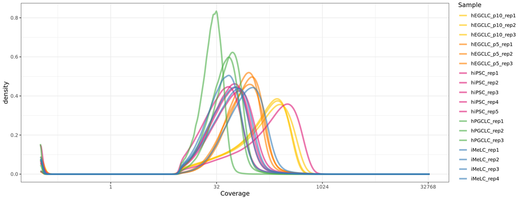

```r
plotEmpiricalDistribution(bsseq_obj,
                          bySample = TRUE,
                          testCovariate = NULL,
                          type = "Cov") + guides(linetype="none") + ggplot2::scale_color_manual(values = sample_colors)
```

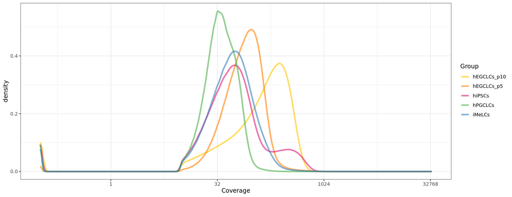

```r
plotEmpiricalDistribution(bsseq_obj,
                          bySample = FALSE,
                          testCovariate = "Type",
                          type = "Cov") + guides(linetype="none") + ggplot2::scale_color_manual(values = cellTypes_colors)
```

## 3.2 Methylation levels distribution for all samples

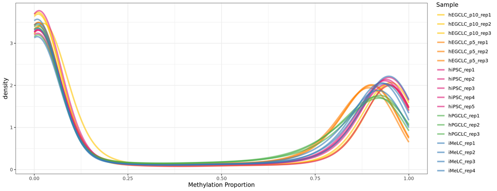

```r
plotEmpiricalDistribution(bsseq_obj,
                          bySample = TRUE,
                          testCovariate = NULL,
                          adj = 3) + guides(linetype="none") + ggplot2::scale_color_manual(values = sample_colors)
```

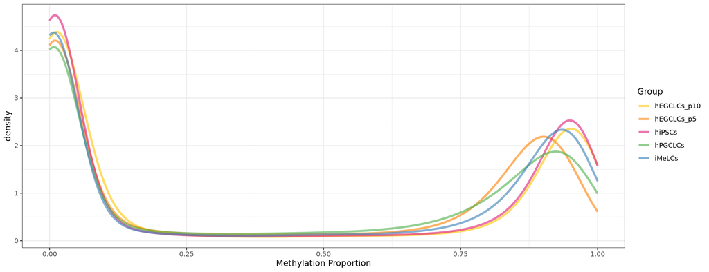

```r
plotEmpiricalDistribution(bsseq_obj,
                          bySample = FALSE,
                          testCovariate = "Type",
                          adj = 3) + guides(linetype="none") + ggplot2::scale_color_manual(values = cellTypes_colors)
```

## 3.3 Violin Plot showing mean

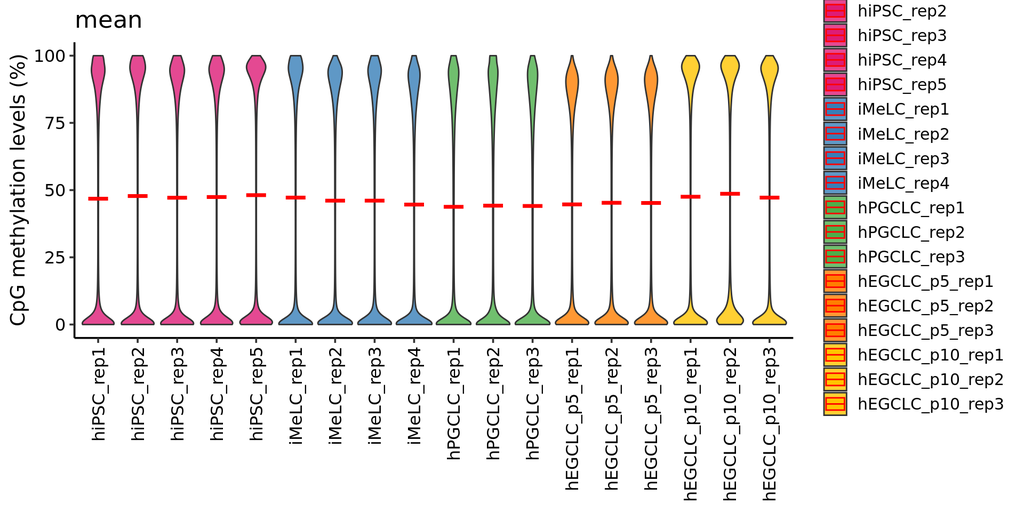

```r
violin_plot(MethPerc_matrix, stat="mean") + ggplot2::scale_fill_manual(values = sample_colors)
## No id variables; using all as measure variables
```

## 3.4 Violin Plot showing median

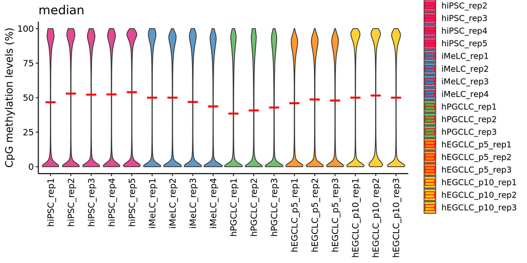

```r
violin_plot(MethPerc_matrix) + ggplot2::scale_fill_manual(values = sample_colors)
## No id variables; using all as measure variables
```

**Mean values for Coverage**

```r
apply(Cov_matrix, 2, mean, na.rm = TRUE)
```

```
##      hiPSC_rep1      hiPSC_rep2      hiPSC_rep3      hiPSC_rep4      hiPSC_rep5
##        42.57113        53.97726        56.50605        63.05298       227.83526
##      iMeLC_rep1      iMeLC_rep2      iMeLC_rep3      iMeLC_rep4     hPGCLC_rep1
##        44.68860        96.10764        53.65240        58.50788        42.69414
##     hPGCLC_rep2     hPGCLC_rep3  hEGCLC_p5_rep1  hEGCLC_p5_rep2  hEGCLC_p5_rep3
##        27.78454        48.42680        91.93421        87.54020        84.00855
## hEGCLC_p10_rep1 hEGCLC_p10_rep2 hEGCLC_p10_rep3
##       182.41638       163.61658       162.38895
```

**Median values for Coverage**

```r
apply(Cov_matrix, 2, median, na.rm = TRUE)
```

```
##      hiPSC_rep1      hiPSC_rep2      hiPSC_rep3      hiPSC_rep4      hiPSC_rep5
##              37              47              49              54             203
##      iMeLC_rep1      iMeLC_rep2      iMeLC_rep3      iMeLC_rep4     hPGCLC_rep1
##              40              83              46              51              40
##     hPGCLC_rep2     hPGCLC_rep3  hEGCLC_p5_rep1  hEGCLC_p5_rep2  hEGCLC_p5_rep3
##              28              46              83              77              76
## hEGCLC_p10_rep1 hEGCLC_p10_rep2 hEGCLC_p10_rep3
##             162             148             149
```

**Mean values for Methylation Proportions**

```r
apply(MethPerc_matrix, 2, mean, na.rm = TRUE)
```

```
##      hiPSC_rep1      hiPSC_rep2      hiPSC_rep3      hiPSC_rep4      hiPSC_rep5
##        46.79386        47.79021        47.15759        47.42451        48.12409
##      iMeLC_rep1      iMeLC_rep2      iMeLC_rep3      iMeLC_rep4     hPGCLC_rep1
##        47.21074        46.07298        46.07659        44.61482        43.78058
##     hPGCLC_rep2     hPGCLC_rep3  hEGCLC_p5_rep1  hEGCLC_p5_rep2  hEGCLC_p5_rep3
##        44.20949        44.09465        44.67909        45.27622        45.21548
## hEGCLC_p10_rep1 hEGCLC_p10_rep2 hEGCLC_p10_rep3
##        47.52772        48.62960        47.20482
```

**Median values for Methylation Proportions**

```r
apply(MethPerc_matrix, 2, median, na.rm = TRUE)
```

```
##      hiPSC_rep1      hiPSC_rep2      hiPSC_rep3      hiPSC_rep4      hiPSC_rep5
##        46.66667        52.94118        52.17391        52.34375        53.96825
##      iMeLC_rep1      iMeLC_rep2      iMeLC_rep3      iMeLC_rep4     hPGCLC_rep1
##        50.00000        50.00000        46.87500        43.63636        38.46154
##     hPGCLC_rep2     hPGCLC_rep3  hEGCLC_p5_rep1  hEGCLC_p5_rep2  hEGCLC_p5_rep3
##        40.74074        42.85714        45.94595        48.67257        47.91667
## hEGCLC_p10_rep1 hEGCLC_p10_rep2 hEGCLC_p10_rep3
##        50.00000        51.53218        50.00000
```

## 3.5 PCA plots

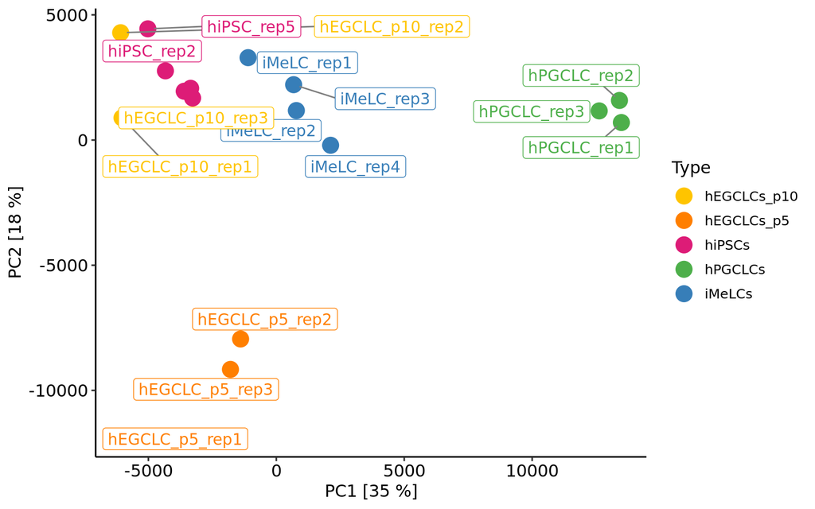

```r
pca_res <- do_PCA(MethPerc_matrix)
plot_PCA(pca_res = pca_res, anno = sample_anno, col_anno = "Type", shape_anno = NULL, custom_colors = cellTypes_colors, point_size = 5, show_labels = TRUE)
```

## 3.6 Dendogram plot

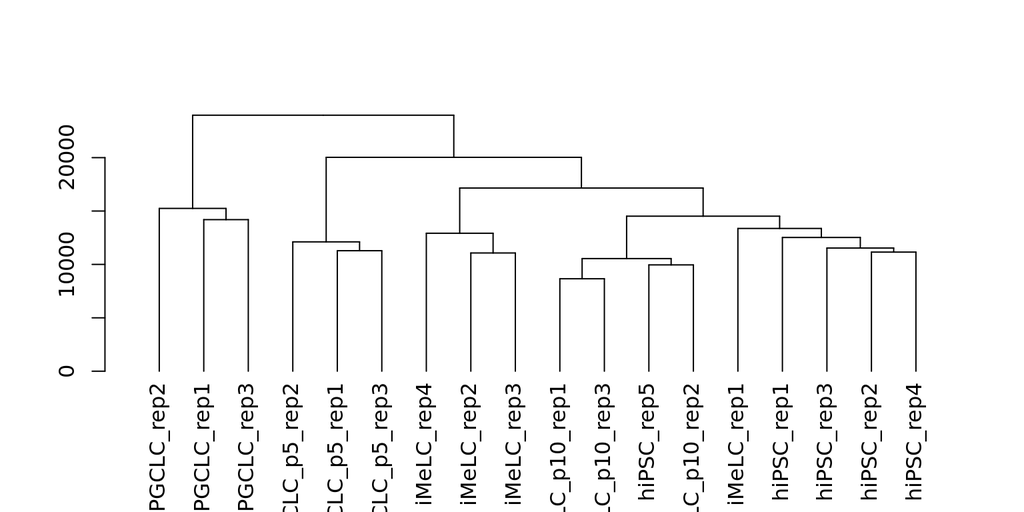

```r
d <- hclust(dist(t(MethPerc_matrix),
                 method="euclidean"))
#d$labels <- rownames(pData(bsseq_obj))
d$labels <- rownames(sample_anno)
  #paste0(pData(bsseq_obj)$Type, "_", pData(bsseq_obj)$InputDNA)
dend <- as.dendrogram(d)
plot(dend)
```

# 4. Filtering BSSeq object by shared CpGs

- The number of samples in the BSSeq object is 18.
- The number of CpGs in the BSSeq object is 3734728.
- The number of CpGs covered by at least 50% of samples in the BSSeq object is 3706258.
- The number of CpGs covered by at least 75% of samples in the BSSeq object is 3644178.
- The number of CpGs covered by all samples in the BSSeq object is 3417412.

```r
table(sample_anno$Type)
```

```
##
## hEGCLCs_p10  hEGCLCs_p5      hiPSCs     hPGCLCs      iMeLCs
##           3           3           5           3           4
```

# 5. Saving and Session Info

Saving BSSeq objects :

- Complete

```r
saveRDS(bsseq_obj, file = paste0 (OutputFolder, "bsseq_obj.rds"))
```

- Filtered by sample and by CpGs covered by all samples kept

```r
saveRDS(methylSig::filter_loci_by_group_coverage(bs = bsseq_obj,group_column = "Line", min_samples_per_group = c("CTL08A" = dim(bsseq_obj)[2])), file = paste0 (OutputFolder, "bsseq_obj_sharedbyall.rds"))
```

- With CpGs covered by 75% of all samples kept

```r
saveRDS(methylSig::filter_loci_by_group_coverage(bs = bsseq_obj,group_column = "Line", min_samples_per_group = c("CTL08A" = round(0.75*dim(bsseq_obj)[2], digits=0))), file = paste0 (OutputFolder, "bsseq_obj_sharedby75ofall.rds"))
```

Session Info

```r
SessionInfo <- sessionInfo()
Date <- date()
```

```r
Date
```

```
## [1] "Thu Jul 24 14:23:00 2025"
```

```r
SessionInfo
```